# Human Activity Prediction - Weightlifting

Raj Maddali

January 22, 2016

**Executive Summary**

We attempt to predict an activity by using data collected by sensors. Based on the quality of the data collected and analysed the model presented below perfoms a good prediction of the activity on the test data set.

**Data Acquisition**

Training and Testing sets data has been provided in two distinct files which are loaded below

```r
Etrain <- read.csv("pml-training.csv")
dim(Etrain)
Etest <- read.csv("pml-testing.csv")
dim(Etest)
```

```
## [1] 19622   160
## [1]  20 160
```

**Data Analysis and Preparation**

Descriptive variables (“X”,“user_name”,“raw_timestamp_part_1”, “raw_timestamp_part_2”, “cvtd_timestamp”,“new_window”,“num_window” ) have been excluded. Also columns with sparse data have been excluded. The data in these sparse columns are summary variables. These steps bring the column count to a more predictible count (52). A corrolation plot below shows that we are left with a vast majority of variables that aren’t strongly correlated to each other.

A display of feature plots of a few variables with high variance displays some deviation by classe. There is a large overlap in their data overlaps. It appears that the dependent variable interaction for each classe is far more complex.

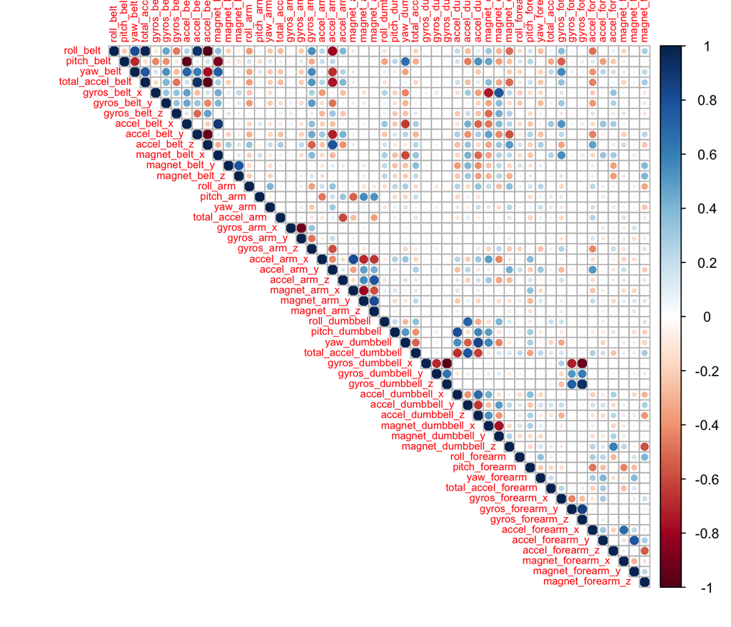

```r
library(caret)
library(matrixStats)
library(plyr)

EtrainX <- Etrain[,-c(1:7)]
indx <- sapply(EtrainX[,-153], is.factor)
EtrainX[indx] <- lapply(EtrainX[indx], function(x) as.numeric(as.character(x)))
Etrain_NZ_Remove0 <- EtrainX[,(colSums(is.na(EtrainX[,-153])))==0 ]

nzv <- nearZeroVar(Etrain_NZ_Remove0[,-153],saveMetrics=TRUE)
Etrain_NZ_Remove <- Etrain_NZ_Remove0[,nzv$nzv==FALSE]

# make trianing set
library(caret)
training <- createDataPartition(y = Etrain_NZ_Remove$classe, p = 0.9, list = FALSE)
Etrain_CV <- Etrain_NZ_Remove[-training, ]
dim(Etrain_CV)

Etrain_TR <- Etrain_NZ_Remove[training, ]
#Etrain_TR <- Etrain_NZ_Remove
dim(Etrain_TR)
classeIndex <- which( colnames(Etrain_TR)=="classe" )

library(corrplot)
cor1 <- cor(Etrain_TR[,-classeIndex])
corrplot(cor1,type="upper",tl.cex = .6)
```

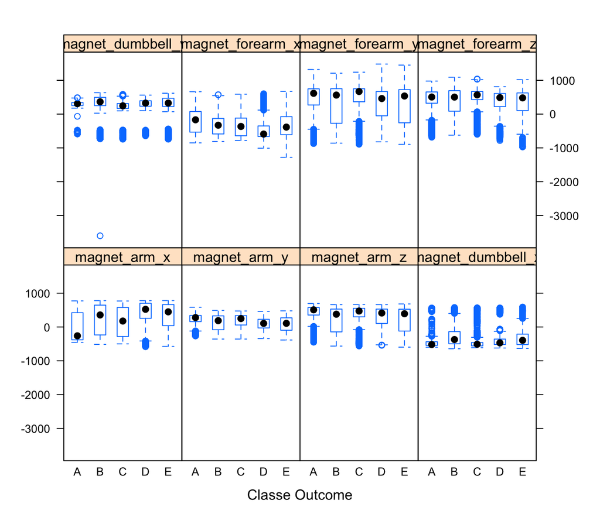

[output not shown]

```r
df1 <- data.frame(apply(Etrain_TR[,1:classeIndex],2,var,na.rm=TRUE))
df1$colNum <- 1:nrow(df1)
names(df1) <- c("coeffs","colnum")
df1 <- arrange(df1,desc(coeffs))
featurePlot(x=Etrain_TR[,c(as.vector(df1$colnum[1:8]))],y=Etrain_TR$classe,plot="box",layout = c(4,2), labels = c("Classe Outcome",""))
```

**Model Building - Tree Model**

There are many variables and the outcome to choose any variant of a General Linear Model. A tree based model leads us to rather unsatisfactory resulst. The classification tree below provides a very mediocre fit. It is very good at classifying classe A, but poor at the other. There are two many variable interactions for good tree performance.

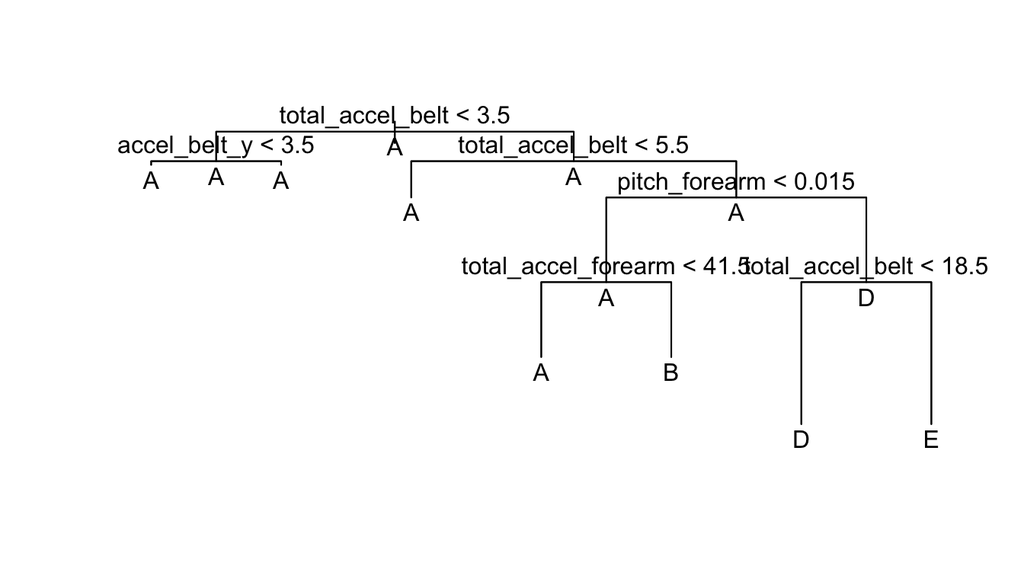

```r
set.seed(12234)
library(tree)
t1 <- tree(classe ~ .,data=Etrain_TR,split=c("gini"),control=tree.control(nobs=dim(Etrain_TR)[1],mincut=2000))
summary(t1)
plot(t1)
text(t1, all = TRUE)
```

```r
t2 <- prune.misclass(t1, best = 6)
#t2
pData1 <- predict(t2, Etrain_TR, type="class")
sum(Etrain_TR$classe==pData1)/length(pData1)
```

[output not shown]

**Model Building - Random Forest**

Random Forest model provides with a very good result. The mtry variable when set to approximately sqrt(Variable) provides a very good result.

```r
set.seed(12234)
library(randomForest)
rfZ1 <- randomForest(classe ~ ., data=Etrain_TR,mtry=7,ntree=500,importance=TRUE)
```

**Model Analyses - Random Forest**

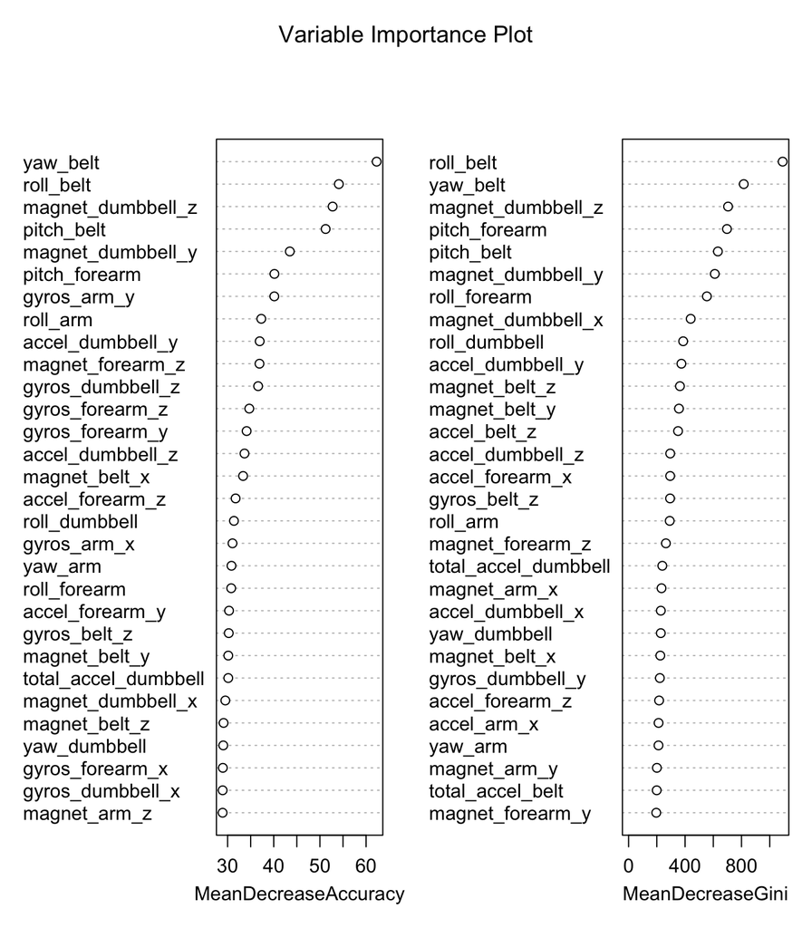

```r
set.seed(12234)
#varImp(rfZ1)
varImpPlot(rfZ1,main="Variable Importance Plot")
```

```r
rfZ1$confusion
print(rfZ1)
```

```
##      A    B    C    D    E  class.error
## A 5021    0    0    0    1 0.0001991239
## B    9 3407    2    0    0 0.0032182563
## C    0   13 3065    2    0 0.0048701299
## D    0    0   20 2872    3 0.0079447323
## E    0    0    1    6 3240 0.0021558362
##
## Call:
##  randomForest(formula = classe ~ ., data = Etrain_TR, mtry = 7,      ntree = 500, importance = TRUE)
##                Type of random forest: classification
##                      Number of trees: 500
## No. of variables tried at each split: 7
##
##         OOB estimate of  error rate: 0.32%
## Confusion matrix:
##      A    B    C    D    E  class.error
## A 5021    0    0    0    1 0.0001991239
## B    9 3407    2    0    0 0.0032182563
## C    0   13 3065    2    0 0.0048701299
## D    0    0   20 2872    3 0.0079447323
## E    0    0    1    6 3240 0.0021558362
```

**Model - Prediction of Test Cases**

The final prediction using the Test set provides the following result. This proved to be a perfect match upon submission into the quiz.

```r
set.seed(12234)
library(randomForest)
predict(rfZ1,newdata=Etest)
```

```
##  1  2  3  4  5  6  7  8  9 10 11 12 13 14 15 16 17 18 19 20
##  B  A  B  A  A  E  D  B  A  A  B  C  B  A  E  E  A  B  B  B
## Levels: A B C D E
```

**Model - Out Of Sample Prediction**

Using the Cross Validation data we get a very good Out of Sample Prediction.

```r
set.seed(12234)
Etrain_CV_Predict <- predict(rfZ1, Etrain_CV)
Etrain_CV_PredictError.accuracy <- sum(Etrain_CV_Predict == Etrain_CV$classe)/length(Etrain_CV_Predict)
1-Etrain_CV_PredictError.accuracy
```

```
## [1] 0.002040816
```